# Introduction

## Distribution of Jungle KDA's

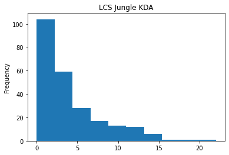

```python
lcs_jng_data[lcs_jng_data['kda'] < 10000]['kda'].plot(title='LCS Jungle KDA', kind='hist');
```

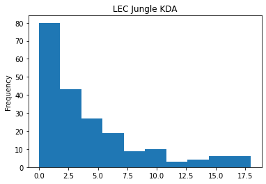

```python
lec_jng_data[lec_jng_data['kda'] < 10000]['kda'].plot(title='LEC Jungle KDA', kind='hist');
```

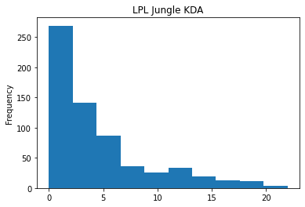

```python
lpl_jng_data[lpl_jng_data['kda'] < 10000]['kda'].plot(title='LPL Jungle KDA', kind='hist');
```

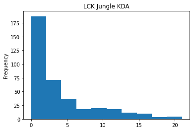

```python
lck_jng_data[lck_jng_data['kda'] < 10000]['kda'].plot(title='LCK Jungle KDA', kind='hist');
```

## My thoughts

Similar to before there is more meat on the bone on the tails of the distributions of LCK and LPL. LEC however also had their own fair share of high KDA jungler games, something that makes sense when you look bakc and consider some of the pop off games that players like Selfmade and Shadow displayed throughout the season. Be that as it may I would refrain from putting too much weight into the insights generated by these distributions as they solely look at kda whilst ignoring all the other random variables that come into play with a game like league. The reason I say this is because despite the presence of high KDA games in LEC I actually do not believe they were playing a similar meta game, during the regular season, as regions like the LPL and LCK were, the prioritization on jungle champions were vastly different after all and the LEC ended up having to play catch up during worlds.

## Distribution of Mid KDA's

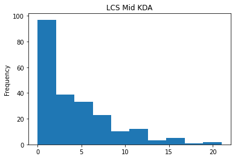

```python
lcs_mid_data[lcs_mid_data['kda'] < 10000]['kda'].plot(title='LCS Mid KDA', kind='hist');
```

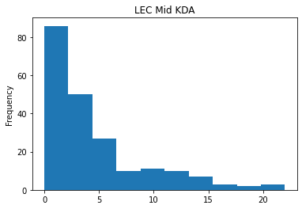

```python
lec_mid_data[lec_mid_data['kda'] < 10000]['kda'].plot(title='LEC Mid KDA', kind='hist');
```

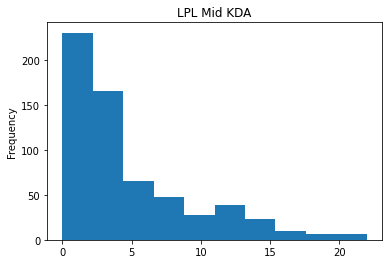

```python
lpl_mid_data[lpl_mid_data['kda'] < 10000]['kda'].plot(title='LPL Mid KDA', kind='hist');
```

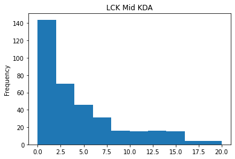

```python
lck_mid_data[lck_mid_data['kda'] < 10000]['kda'].plot(title='LCK Mid KDA', kind='hist');
```

## My thoughts

When looking at the tails of the distribution what I found to be so odd was how thin the tail of the LCS distribution is. While by itself it isn't indicative of much when one merges it with the knowledge of how much, or rather how little, actual mid lane talent is present within the LCS, relative to other regions, it only serves to enhance my perception that the pop off potential of North American mid laners is lacking in comparison to other regions. For example looking at the tail of LCK's distribution it is remarkable how many instances there actually are between the 7.5 to 16 range in KDA. The tail of LCK's distribution in mids also becomes far more remarkable when you realize that the scale of frequency of the graph is at a higher magnitude level than the one of LCS and LEC. While people constantly bring up the remark of "European mids", and rightfully so, the LCK as a whole is probably the strongest region for mid lane ever.However the LEC is not one to be outshown either as the LEC also has a lengthy tail in its distribution of KDA, and this structure only seems to sync up well with the public perception of the deep strength present within LEC's mid lane pool.

## Distribution of BOT KDA's

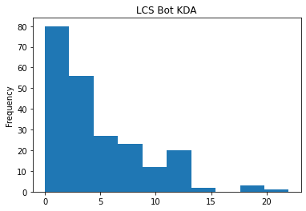

```python
lcs_bot_data[lcs_bot_data['kda'] < 10000]['kda'].plot(title='LCS Bot KDA', kind='hist');
```

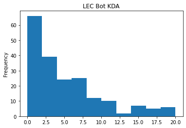

```python
lec_bot_data[lec_bot_data['kda'] < 10000]['kda'].plot(title='LEC Bot KDA', kind='hist');
```

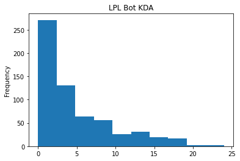

```python
lpl_bot_data[lpl_bot_data['kda'] < 10000]['kda'].plot(title='LPL Bot KDA', kind='hist');
```

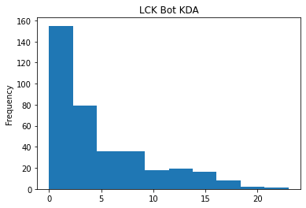

```python
lck_bot_data[lck_bot_data['kda'] < 10000]['kda'].plot(title='LCK Bot KDA', kind='hist');
```

## My thoughts

As I continously scroll down looking at distributions of KDA's it becomes clear that the LCS region as a whole tends to have less presence within the tails of the distribution when compared to the distributions of some of the other regions. What I would like to posit is that perhaps this is reflective of the type of play of the region itself. People always claim that NA as a whole focuses too much on team fighting, mid lane, and lacks the proper side lane control and map movements that other regions consider fundamental to a good game of league of legends. What that increased fighting does, logically, is also lower KDA's as your chances of death would be higher.

Another thing that popped into my head looking at these graphs was that the LEC tail actually had a decent amount of instances. This goes to show the strength of the LEC marksman pool, something that unequivocally had taken a large step up this year thanks to the influx of mechanical talents such as Carzzy, Comp, Crownshot that served to bolster an already impressive pool consisting of players like Rekkles, Upset etc. This only bodes well for the level of ADC play that should be coming out of the LEC region in the upcoming days, the future only looks bright for LEC marksman.

## Distribution of support KDA's

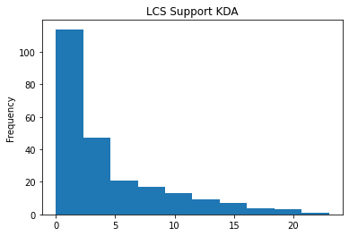

```python
lcs_sup_data[lcs_sup_data['kda'] < 10000]['kda'].plot(title='LCS Support KDA',  kind='hist');
```

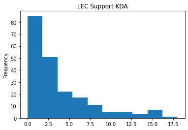

```python
lec_sup_data[lec_sup_data['kda'] < 10000]['kda'].plot(title='LEC Support KDA',  kind='hist');
```

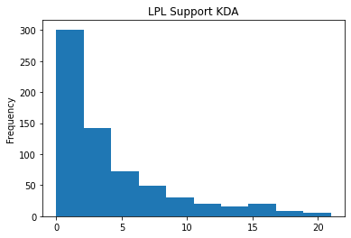

```python
lpl_sup_data[lpl_sup_data['kda'] < 10000]['kda'].plot(title='LPL Support KDA',  kind='hist');
```

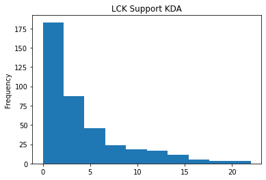

```python
lck_sup_data[lck_sup_data['kda'] < 10000]['kda'].plot(title='LCK Support KDA',  kind='hist');
```

## My thoughts

These are support distributions that I plotted for continuity purposes. Personally I don't think there is as much to glean from statistics in regards to support play, or rather there is not much to glean from statistics pertaining to supports as they are currently structured. I feel that there are paramaters and avenues of interest that would provide a good lense into support play, I just am not sure KDA is one of them.

## First blood victims

```python
def plotFirstBloodVictims(dftop, dfjng, dfmid, dfbot, dfsup):
    labels = ['TOP', 'JNG', 'MID', 'BOT', 'SUP']
    frequencies = [len(dftop[dftop['firstbloodvictim'] == 1]), len(dfjng[dfjng['firstbloodvictim'] == 1]), len(dfmid[dfmid['firstbloodvictim'] == 1]), len(dfbot[dfbot['firstbloodvictim'] == 1]), len(dfsup[dfsup['firstbloodvictim'] == 1]),]
    fig, ax = plt.subplots()
    ax.pie(frequencies, labels=labels, shadow=True, autopct = '%1.2f%%')
    plt.title("%s First Blood Victim %%" %(dftop.league.iloc[0]))
    plt.show()
```

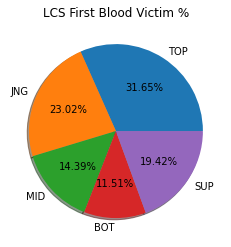

```python
plotFirstBloodVictims(lcs_top_data, lcs_jng_data, lcs_mid_data, lcs_bot_data, lcs_sup_data)
```

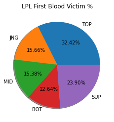

```python
plotFirstBloodVictims(lpl_top_data, lpl_jng_data, lpl_mid_data, lpl_bot_data, lpl_sup_data)
```

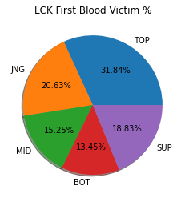

```python
plotFirstBloodVictims(lck_top_data, lck_jng_data, lck_mid_data, lck_bot_data, lck_sup_data)
```

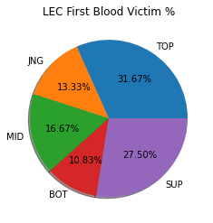

```python
plotFirstBloodVictims(lec_top_data, lec_jng_data, lec_mid_data, lec_bot_data, lec_sup_data)
```

## My thoughts

Immediately I realized that top lane is truly a mans role. After all across all regions they are responsible for over 30% of the first bloods in every game, something that shouldn't come as too much of a surprise when you consider that they are the only individuals on the map playing solo in a long lane. From there what stood out ot me was how in LCK and LCS junglers were responsible for over 20% of the first bloods, while in LPL and LEC that over 20% allocation of first blood's actually fell on the shoulders of the supports. What I would posit as the reason for that in LEC and LPL is the strength of their ADC's. LPL has always historically had extremely strong mechanical talents coming out of the ADC role, after all they are the region that has given us names like Weixaoi, UZI, Namei, Jackeylove to name a few. Similarly the LEC marksman talent pool has actually, over the last few seasons of incremental progress, become arguably its strongest role (in competition with mid). When you look at the LEC marksman pool immediatley stud talents like Rekkles, Upset, Carzzy begin to illustrate the depth of talent within the region.

# Gold Difference at 15 broken down by Role

## Top

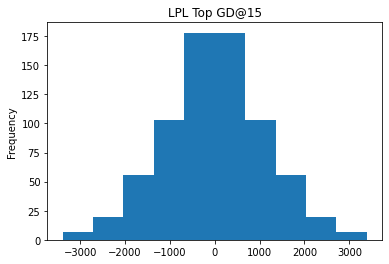

```python
lpl_top_data.golddiffat15.plot(title='LPL Top GD@15',  kind='hist');
```

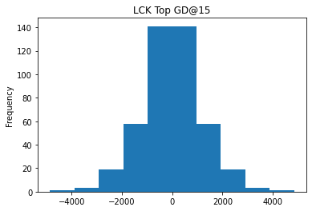

```python
lck_top_data.golddiffat15.plot(title='LCK Top GD@15', kind='hist');
```

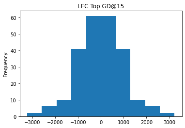

```python
lec_top_data.golddiffat15.plot(title='LEC Top GD@15', kind='hist');
```

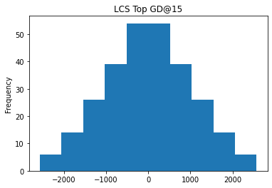

```python
lcs_top_data.golddiffat15.plot(title='LCS Top GD@15', kind='hist');
```

## My thoughts

Before starting off my soliloquy I would like to preface this be putting in the readers mind that all gold difference distributions will inherently look symmetric as whenever a player had a 1k gold lead over his enemy laner the enemy laner would have the same data point only in the negative. Now that I have established that premise I would like to point out the difference in the the ranges of the distribution across the regions. For LCS the maximum gold difference in the top lane at 15 minutes was only around 2500, which by itself is a respectable gold lead after all thats roughly one item. However when you compare that to to the other regions the disparity quickly jumps to the forefront. LPL and LEC both have had multiple instances of people geenrating over a 3k gold lead, and in the case of LCK, the preeminent home of some of the world's greatest top lane carry threats, some people have even managed to generate over a 4k gold lead. In my eyes this servers to show the difference in style of play as there has to be a concerted effort as a team in order to enable a top laner to carry. On the contrary some might point to a lack of top lane talent as being the reason for this, but in my eyes this can't be the primary factor as there actually is some quality top lane talent in North America (even if there original roots may have been in Korea).

## Jng

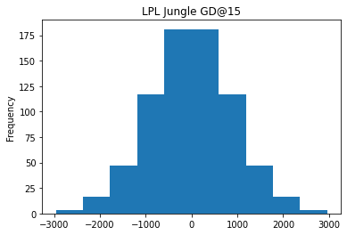

```python
lpl_jng_data.golddiffat15.plot(title='LPL Jungle GD@15', kind='hist');
```

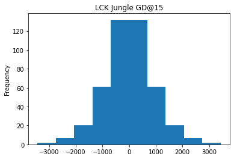

```python
lck_jng_data.golddiffat15.plot(title='LCK Jungle GD@15', kind='hist');
```

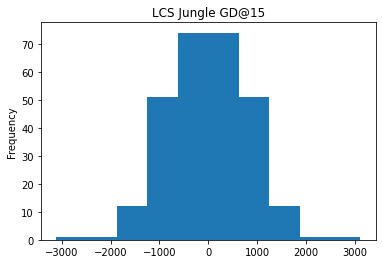

```python
lcs_jng_data.golddiffat15.plot(title='LCS Jungle GD@15', kind='hist');
```

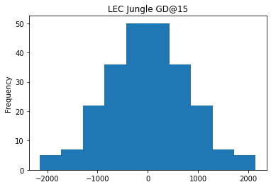

```python
lec_jng_data.golddiffat15.plot(title='LEC Jungle GD@15', kind='hist');
```

## My thoughts

In the case of the jungle distributions my eyes immediately jumped to the LEC distribution due to the limit in the ranges of said distributions. In the case of LEC the largest gold lead generated by the jungle position was just barely over 2k, whereas in the cases of other regions they managed to generate gold leads above or just around the 3k gold mark. While a 1k gold difference doesn't seem like much the disparity becomes clearer when you consider that the 15 minute mark leaves the game still in a mid game position. As such as the game goes farther on said disparity would only grow larger. In my eyes this ties into the statements that G2 made in regards to their experience at worlds, specifically how they maintained that they had to play catchup in regards to the carry jungle specific meta that was prevalent at worlds.

While I did comment on the LEC's distribution I would undoubtedly be remiss to ignore the LCS distribution. While the range of it seems to point to a carry jungle meta presence within the LCS something has to be said in regards to how thin the tail of the distribution actually is. The majority of the distribution seems to be centered around the 1500 range, which actually goes to show how the LCS was also not well adapted to the worlds meta going in. The style of play that the western regions were exhibiting was not akin to the style that was played by the asian regions throughout the season, and also the meta that ultimately came to dominate at worlds.

## Mid

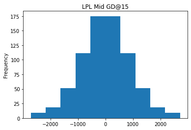

```python
lpl_mid_data.golddiffat15.plot(title='LPL Mid GD@15', kind='hist');
```

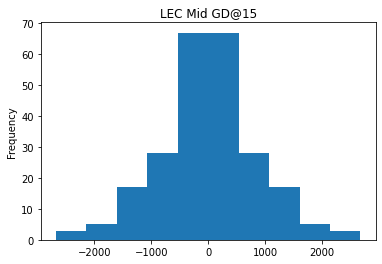

```python
lec_mid_data.golddiffat15.plot(title='LEC Mid GD@15', kind='hist');
```

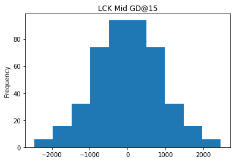

```python
lck_mid_data.golddiffat15.plot(title='LCK Mid GD@15', kind='hist');
```

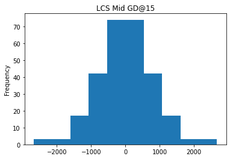

```python
lcs_mid_data.golddiffat15.plot(title='LCS Mid GD@15', kind='hist');
```

## My thoughts

The LEC, LCK, and LPL distributions are actually pretty similar in regards to structure, the large differences, for example the thinner tail in the case of LEC, can largely be attributed to volume differences in terms of how many games were actually played by each league. However when you compare the LEC graph to the LCS graph there is a clear disparity in that the LCS tail is even skinnier than the LEC one. For some reason the style of play itself within the LCS region is far less conducive to high gold differences. One idea that could be posited to account for this difference could be the general passivity and the focus on team fights in the NA LCS region. While everyone does remark that the style of play in the LCS usually does come down to team fights, as opposed to other regions like LEC where general meta strategies like side laning also thrive, there actually are not as many skirmishes or team fights as there is in a region like LPL. In the case of LCS the region exhibits a tendency towards team fights in conjunction with a general level of passivity that, at least in my eyes, can inhibit truly large levels of gold leads from being generated.

## Bot

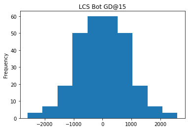

```python
lcs_bot_data.golddiffat15.plot(title='LCS Bot GD@15', kind='hist');
```

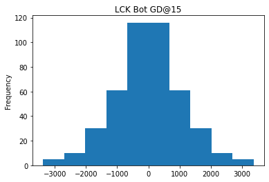

```python
lck_bot_data.golddiffat15.plot(title='LCK Bot GD@15', kind='hist');
```

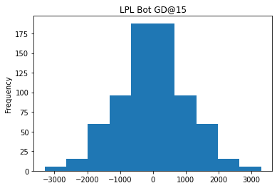

```python
lpl_bot_data.golddiffat15.plot(title='LPL Bot GD@15', kind='hist');
```

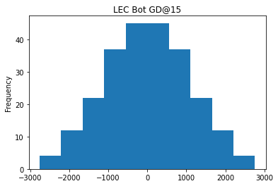

```python
lec_bot_data.golddiffat15.plot(title='LEC Bot GD@15', kind='hist');
```